# Aufgabenblatt 1

Datenanalyse und Visualisierung mit R

Ömer Faruk Torun

2025-04-14

# Aufgabe 1: Übersicht und Datenqualität

1. Geben Sie eine Übersicht über den Datensatz mit den Funktionen summary() und skim().

   ```r
   library(tidyverse) # Read .csv files
   benzfinal <- read_csv("data/benzfinal.csv") %>% # Load the dataset
     mutate(Model = str_remove_all(Model, "\""))
   summary(benzfinal) # Einen kurzen Übersicht geben
   ```

   ```
   ##  Manufacturer          Model               Month             Year
   ##  Length:521         Length:521         Min.   : 1.000   Min.   :1953
   ##  Class :character   Class :character   1st Qu.: 3.000   1st Qu.:2016
   ##  Mode  :character   Mode  :character   Median : 5.000   Median :2017
   ##                                        Mean   : 5.591   Mean   :2014
   ##                                        3rd Qu.: 8.000   3rd Qu.:2018
   ##                                        Max.   :12.000   Max.   :2018
   ##                                        NA's   :100      NA's   :2
   ##        Km               Kw              Ps            Price
   ##  Min.   :     0   Min.   :  0.0   Min.   :  0.0   Min.   :  60000
   ##  1st Qu.:   999   1st Qu.:190.0   1st Qu.:258.0   1st Qu.:  64990
   ##  Median :  9060   Median :230.0   Median :313.0   Median :  73680
   ##  Mean   : 16133   Mean   :251.5   Mean   :341.9   Mean   : 107796
   ##  3rd Qu.: 22000   3rd Qu.:331.0   3rd Qu.:450.0   3rd Qu.:  93600
   ##  Max.   :176000   Max.   :588.0   Max.   :799.0   Max.   :3000000
   ##
   ##      state            engine           Benz
   ##  Min.   :0.0000   Min.   :0.0000   Length:521
   ##  1st Qu.:0.0000   1st Qu.:0.0000   Class :character
   ##  Median :0.0000   Median :1.0000   Mode  :character
   ##  Mean   :0.2342   Mean   :0.5221
   ##  3rd Qu.:0.0000   3rd Qu.:1.0000
   ##  Max.   :1.0000   Max.   :1.0000
   ##
   ```

   ```r
   library(skimr)
   skim(benzfinal) # Eine zusammenfassende Statistiken geben
   ```

   Data summary

   | Name | benzfinal |
   | --- | --- |
   | Number of rows | 521 |
   | Number of columns | 11 |
   | _______________________ |  |
   | Column type frequency: |  |
   | character | 3 |
   | numeric | 8 |
   | ________________________ |  |
   | Group variables | None |

   **Variable type: character**

   | skim_variable | n_missing | complete_rate | min | max | empty | n_unique | whitespace |
   | --- | --- | --- | --- | --- | --- | --- | --- |
   | Manufacturer | 0 | 1 | 4 | 16 | 0 | 521 | 0 |
   | Model | 0 | 1 | 1 | 8 | 0 | 82 | 0 |
   | Benz | 0 | 1 | 2 | 3 | 0 | 2 | 0 |

   **Variable type: numeric**

   | skim_variable | n_missing | complete_rate | mean | sd | p0 | p25 | p50 | p75 | p100 | hist |
   | --- | --- | --- | --- | --- | --- | --- | --- | --- | --- | --- |
   | Month | 100 | 0.81 | 5.59 | 3.42 | 1 | 3 | 5 | 8 | 12 | ▇▅▃▃▅ |
   | Year | 2 | 1.00 | 2014.40 | 10.56 | 1953 | 2016 | 2017 | 2018 | 2018 | ▁▁▁▁▇ |
   | Km | 0 | 1.00 | 16133.45 | 20825.77 | 0 | 999 | 9060 | 22000 | 176000 | ▇▁▁▁▁ |
   | Kw | 0 | 1.00 | 251.52 | 98.17 | 0 | 190 | 230 | 331 | 588 | ▁▇▅▂▁ |
   | Ps | 0 | 1.00 | 341.93 | 133.51 | 0 | 258 | 313 | 450 | 799 | ▁▇▅▂▁ |
   | Price | 0 | 1.00 | 107796.19 | 193840.41 | 60000 | 64990 | 73680 | 93600 | 3000000 | ▇▁▁▁▁ |
   | state | 0 | 1.00 | 0.23 | 0.42 | 0 | 0 | 0 | 0 | 1 | ▇▁▁▁▂ |
   | engine | 0 | 1.00 | 0.52 | 0.50 | 0 | 0 | 1 | 1 | 1 | ▇▁▁▁▇ |

2. Visualisieren Sie die fehlenden Datenpunkte mit der Funktion plot_missing().

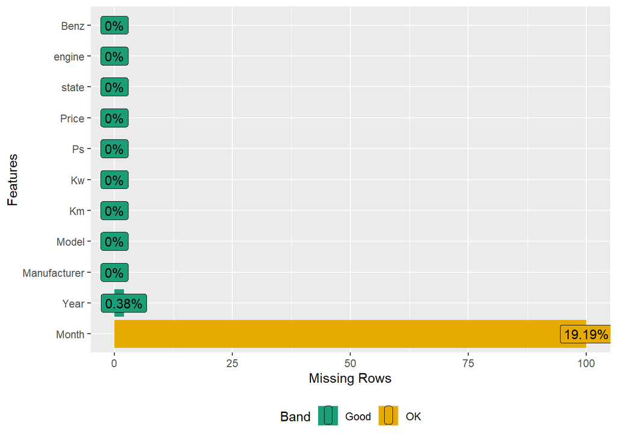

   ```r
   library(DataExplorer) # Data manipulation
   plot_missing(benzfinal) # Visualisieren Sie die fehlenden Datenpunkte
   ```

# Aufgabe 2: Erstellen neuer Variablen

1. Erstellen Sie eine neue Variable Sport_wagen, die den Wert 1 hat, wenn die PS > 300 sind, und 0 ansonsten.

   ```r
   benzfinal$Sportwagen <- ifelse(benzfinal$Ps > 300, 1, 0)
   benzfinal %>%
     select("Manufacturer", "Ps", "Sportwagen") %>%
     head() %>% # Geben Sie die ersten 10 Zeilen aus
     kable(caption = "Erste 10 Zeilen mit Sportwagen")
   ```

   | Manufacturer | Ps | Sportwagen |
   | --- | --- | --- |
   | Mercedes-Benz1 | 367 | 1 |
   | Mercedes-Benz2 | 190 | 0 |
   | Mercedes-Benz3 | 476 | 1 |
   | Mercedes-Benz4 | 211 | 0 |
   | Mercedes-Benz5 | 194 | 0 |
   | Mercedes-Benz6 | 258 | 0 |

2. Erstellen Sie eine neue Variable Luxus_Auto, die den Wert 1 hat, wenn der Preis > 200.000 und die PS > 400 sind.

   ```r
   benzfinal$Luxus_Auto <-
     ifelse(benzfinal$Price > 200000 & benzfinal$Ps > 400, 1, 0)
   benzfinal %>%
     select("Manufacturer", "Price", "Ps", "Luxus_Auto") %>%
     head() %>% # Geben Sie die ersten 10 Zeilen aus
     kable(caption = "Erste 10 Zeilen mit Luxus Autos")
   ```

   | Manufacturer | Price | Ps | Luxus_Auto |
   | --- | --- | --- | --- |
   | Mercedes-Benz1 | 69695 | 367 | 0 |
   | Mercedes-Benz2 | 63589 | 190 | 0 |
   | Mercedes-Benz3 | 60490 | 476 | 0 |
   | Mercedes-Benz4 | 60500 | 211 | 0 |
   | Mercedes-Benz5 | 60678 | 194 | 0 |
   | Mercedes-Benz6 | 71990 | 258 | 0 |

# Aufgabe 3: Filtern und Auswählen

1. Filtern Sie alle Autos, die sowohl Sport_wagen als auch Luxus_Auto sind, und speichern Sie die Ergebnisse in einer neuen Tabelle luxury_sport.

   ```r
   luxury_sport <- benzfinal %>%
     filter(Sportwagen == 1 & Luxus_Auto == 1)
   head(luxury_sport %>% select("Manufacturer", "Model", "Price", "Ps"), 10) %>%
     kable(caption = "Erste 10 Zeilen mit Luxus Sportwagen")
   ```

   Erste 10 Zeilen mit Luxus Sportwagen

   | Manufacturer | Model | Price | Ps |
   | --- | --- | --- | --- |
   | Mercedes-Benz50 | SLR | 399800 | 625 |
   | Mercedes-Benz53 | S | 230000 | 455 |
   | Mercedes-Benz101 | G | 1100000 | 630 |
   | Mercedes-Benz115 | G | 279850 | 700 |
   | Mercedes-Benz117 | S | 217770 | 612 |
   | Mercedes-Benz134 | G | 236810 | 421 |
   | Mercedes-Benz135 | S | 475000 | 530 |
   | Mercedes-Benz141 | SLS | 399000 | 591 |
   | Mercedes-Benz182 | SLS | 209950 | 571 |
   | Mercedes-Benz192 | G | 285000 | 678 |

2. Filtern Sie alle Autos mit “Mercedes-Benz”, deren Preis > 300.000 oder PS > 400, und speichern Sie nur die Spalten Model, Km, Ps, Price. Nennen Sie die Tabelle last_df.

   ```r
   mercedes_filter <- str_detect(benzfinal$Manufacturer, "^Mercedes-Benz")
   last_df <- benzfinal %>%
     filter(mercedes_filter & (Price > 300000 | Ps > 400)) %>%
     select(Model, Km, Ps, Price)
   head(last_df, 10) %>%
     kable(caption = "Erste 10 Zeilen mit Mercedes-Benz Autos")
   ```

   Erste 10 Zeilen mit Mercedes-Benz Autos

   | Model | Km | Ps | Price |
   | --- | --- | --- | --- |
   | C | 9060 | 476 | 60490 |
   | C | 29440 | 476 | 60889 |
   | C | 22174 | 476 | 60900 |
   | G | 40322 | 620 | 157989 |
   | GT | 5892 | 476 | 111111 |
   | S | 20 | 469 | 151890 |
   | AMG | 9060 | 476 | 60490 |
   | AMG | 27000 | 510 | 129000 |
   | GT | 8900 | 630 | 124900 |
   | GLE | 3388 | 557 | 107770 |

# Aufgabe 4: Datenanalyse und Aggregation

1. Berechnen Sie die durchschnittlichen PS (Ps) für jede Manufacturer.

   ```r
   library(knitr) # For kable function
   benzfinal %>%
     # Die Hersteller extrahieren:
     mutate(Manufacturer = str_extract(Manufacturer, "^[A-Za-z\\-]+")) %>%
     # Gruppieren Sie die Daten nach Hersteller:
     group_by(Manufacturer) %>%
     # Berechnen Sie den Durchschnitt der PS:
     summarise(avg_Ps = mean(Ps, na.rm = TRUE)) %>%
     # Sortieren Sie die Daten nach dem Durchschnitt der PS:
     arrange(desc(avg_Ps)) %>%
     # Visualisieren Sie die Ergebnisse:
     kable(caption = "Durchschnittliche PS pro Hersteller")
   ```

   Durchschnittliche PS pro Hersteller

   | Manufacturer | avg_Ps |
   | --- | --- |
   | Mercedes-Benz | 350.4669 |
   | BMW | 332.5944 |

2. Berechnen Sie die Anzahl der Autos pro Jahr (Year) und visualisieren Sie die Ergebnisse:  
   Nutzen Sie piping mit `(group_by() dann summarise(count=n()))`

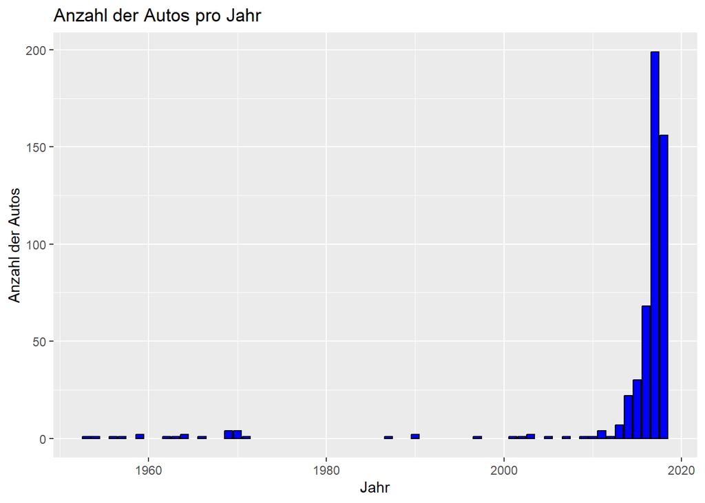

   ```r
   benzfinal %>%
     group_by(Year) %>%
     summarise(count = n()) %>% # Anzahl der Autos pro Jahr berechnen
     ggplot(aes(x = Year, y = count)) +
     geom_bar(stat = "identity", fill = "blue", color = "black") +
     labs(title = "Anzahl der Autos pro Jahr",
          x = "Jahr",
          y = "Anzahl der Autos")
   ```

# Aufgabe 5: String-Verarbeitung

1. Filtern Sie alle Autos, deren Model mit “GL” beginnt, unter Verwendung von str_detect().

   ```r
   benzfinal %>%
     filter(str_detect(Model, "^GL")) %>%
     select(Model, Manufacturer, Price, Ps) %>%
     kable(caption = "Autos, deren Model mit 'GL' beginnt")
   ```

   Autos, deren Model mit ‘GL’ beginnt

   | Model | Manufacturer | Price | Ps |
   | --- | --- | --- | --- |
   | GLE | Mercedes-Benz1 | 69695 | 367 |
   | GLC | Mercedes-Benz4 | 60500 | 211 |
   | GLS | Mercedes-Benz6 | 71990 | 258 |
   | GLS | Mercedes-Benz8 | 79990 | 258 |
   | GLE | Mercedes-Benz9 | 60880 | 258 |
   | GLE | Mercedes-Benz18 | 61250 | 204 |
   | GLC | Mercedes-Benz19 | 61500 | 258 |
   | GLC | Mercedes-Benz21 | 61899 | 245 |
   | GLC | Mercedes-Benz23 | 61970 | 258 |
   | GLE | Mercedes-Benz36 | 90565 | 390 |
   | GLE | Mercedes-Benz37 | 76500 | 367 |
   | GLE | Mercedes-Benz42 | 88691 | 258 |
   | GLE | Mercedes-Benz43 | 107770 | 557 |
   | GLC | Mercedes-Benz51 | 127330 | 510 |
   | GLE | Mercedes-Benz54 | 64780 | 258 |
   | GLC | Mercedes-Benz62 | 74990 | 211 |
   | GLE | Mercedes-Benz64 | 71900 | 258 |
   | GLC | Mercedes-Benz65 | 60000 | 211 |
   | GLC | Mercedes-Benz66 | 60000 | 211 |
   | GLC | Mercedes-Benz68 | 64888 | 258 |
   | GLC | Mercedes-Benz81 | 60160 | 170 |
   | GLC | Mercedes-Benz85 | 60291 | 211 |
   | GLC | Mercedes-Benz86 | 60297 | 211 |
   | GLE | Mercedes-Benz88 | 69880 | 258 |
   | GLC | Mercedes-Benz95 | 91750 | 476 |
   | GLE | Mercedes-Benz102 | 88923 | 258 |
   | GLE | Mercedes-Benz108 | 77776 | 333 |
   | GLC | Mercedes-Benz111 | 62820 | 204 |
   | GLE | Mercedes-Benz116 | 99900 | 585 |
   | GLE | Mercedes-Benz119 | 71930 | 367 |
   | GLE | Mercedes-Benz120 | 80900 | 455 |
   | GLE | Mercedes-Benz126 | 72880 | 258 |
   | GLC | Mercedes-Benz145 | 62777 | 258 |
   | GLE | Mercedes-Benz164 | 66900 | 258 |
   | GLE | Mercedes-Benz165 | 73990 | 258 |
   | GLE | Mercedes-Benz166 | 77980 | 258 |
   | GLE | Mercedes-Benz168 | 68950 | 258 |
   | GLE | Mercedes-Benz180 | 65850 | 435 |
   | GLC | Mercedes-Benz181 | 60349 | 258 |
   | GLS | Mercedes-Benz185 | 79850 | 258 |
   | GLE | Mercedes-Benz189 | 73700 | 258 |
   | GLE | Mercedes-Benz198 | 71380 | 258 |
   | GLE | Mercedes-Benz207 | 68600 | 258 |
   | GLE | Mercedes-Benz216 | 75880 | 258 |
   | GLC | Mercedes-Benz230 | 68887 | 258 |
   | GLE | Mercedes-Benz233 | 64930 | 258 |
   | GLE | Mercedes-Benz237 | 71590 | 367 |
   | GLE | Mercedes-Benz249 | 72222 | 258 |
   | GLE | Mercedes-Benz250 | 127959 | 585 |
   | GLE | Mercedes-Benz254 | 69900 | 367 |
   | GLE | Mercedes-Benz258 | 65880 | 258 |
   | GLE | Mercedes-Benz263 | 68880 | 367 |
   | GLE | Mercedes-Benz268 | 78995 | 258 |

2. Erstellen Sie eine neue Variable SUV, die den Wert “Ja” hat, wenn der Model-Name “GL” oder “X” enthält, und “Nein” ansonsten, mithilfe von case_when().

   ```r
   benzfinal <- benzfinal %>%
     mutate(SUV = case_when(
       str_detect(Model, "GL") ~ "Ja",
       str_detect(Model, "X") ~ "Ja",
       TRUE ~ "Nein"
     ))
   benzfinal %>%
     subset(str_detect(Model, "GL") | str_detect(Model, "X")) %>%
     select(Model, Manufacturer, SUV) %>%
     kable(caption = "SUVs mit 'GL' oder 'X' im Model-Namen")
   ```

   SUVs mit ‘GL’ oder ‘X’ im Model-Namen

   | Model | Manufacturer | SUV |
   | --- | --- | --- |
   | GLE | Mercedes-Benz1 | Ja |
   | GLC | Mercedes-Benz4 | Ja |
   | GLS | Mercedes-Benz6 | Ja |
   | GLS | Mercedes-Benz8 | Ja |
   | GLE | Mercedes-Benz9 | Ja |
   | GLE | Mercedes-Benz18 | Ja |
   | GLC | Mercedes-Benz19 | Ja |
   | GLC | Mercedes-Benz21 | Ja |
   | GLC | Mercedes-Benz23 | Ja |
   | GLE | Mercedes-Benz36 | Ja |
   | GLE | Mercedes-Benz37 | Ja |
   | GLE | Mercedes-Benz42 | Ja |
   | GLE | Mercedes-Benz43 | Ja |
   | GLC | Mercedes-Benz51 | Ja |
   | GLE | Mercedes-Benz54 | Ja |
   | GLC | Mercedes-Benz62 | Ja |
   | GLE | Mercedes-Benz64 | Ja |
   | GLC | Mercedes-Benz65 | Ja |
   | GLC | Mercedes-Benz66 | Ja |
   | GLC | Mercedes-Benz68 | Ja |
   | GLC | Mercedes-Benz81 | Ja |
   | GLC | Mercedes-Benz85 | Ja |
   | GLC | Mercedes-Benz86 | Ja |
   | GLE | Mercedes-Benz88 | Ja |
   | GLC | Mercedes-Benz95 | Ja |
   | GLE | Mercedes-Benz102 | Ja |
   | GLE | Mercedes-Benz108 | Ja |
   | GLC | Mercedes-Benz111 | Ja |
   | GLE | Mercedes-Benz116 | Ja |
   | GLE | Mercedes-Benz119 | Ja |

   [output cut: 99 more lines]

# Aufgabe 6: Statistische Berechnungen

1. Erstellen Sie ein Histogramm der PS-Werte (Ps) für alle Autos.

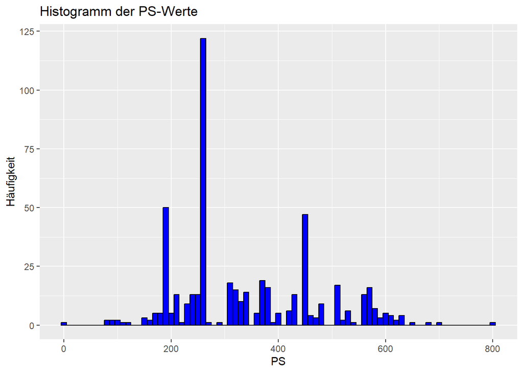

   ```r
   benzfinal %>%
     ggplot(aes(x = Ps)) +
     geom_histogram(binwidth = 10, fill = "blue", color = "black") +
     labs(title = "Histogramm der PS-Werte",
          x = "PS",
          y = "Häufigkeit")
   ```

# Aufgabe 7: Visualisierung

1. Erstellen Sie ein Streudiagramm von Preis (Price) gegen PS (Ps), farbcodiert nach Manufacturer.

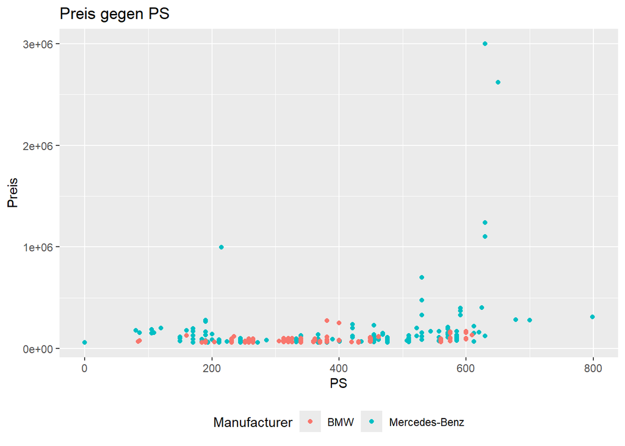

   ```r
   benzfinal %>%
     mutate(Manufacturer = str_extract(Manufacturer, "^[A-Za-z\\-]+")) %>%
     ggplot(aes(x = Ps, y = Price, color = Manufacturer)) +
     geom_point() +
     labs(title = "Preis gegen PS",
          x = "PS",
          y = "Preis") +
     theme(legend.position = "bottom")
   ```

2. Visualisieren Sie die Verteilung der Autos pro Year mit einem Balkendiagramm.

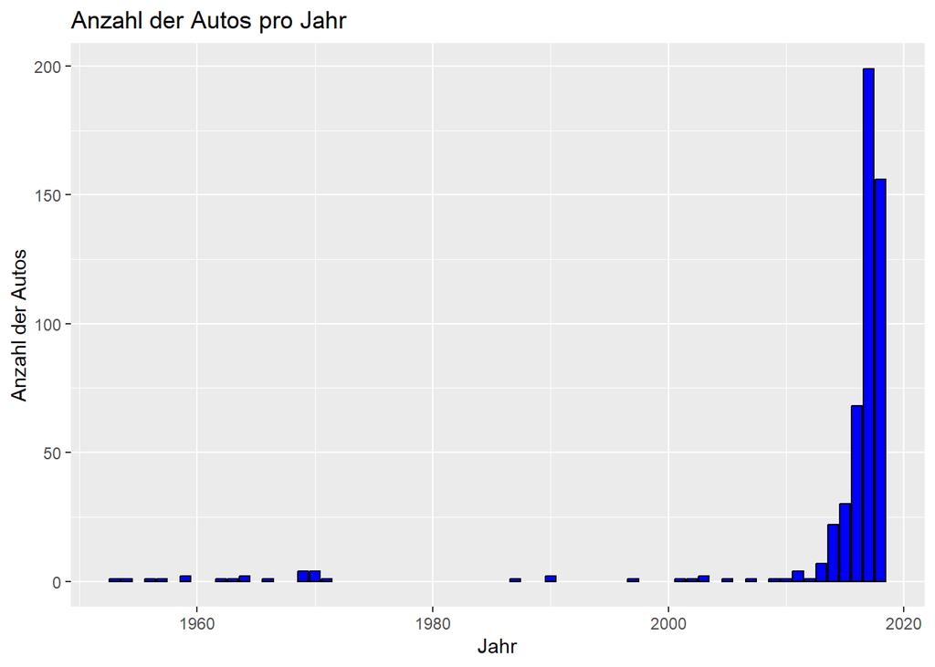

   ```r
   benzfinal %>%
     ggplot(aes(x = Year)) +
     geom_bar(fill = "blue", color = "black") +
     labs(title = "Anzahl der Autos pro Jahr",
          x = "Jahr",
          y = "Anzahl der Autos")
   ```